# Inferential Data Analysis for Exponantial Distribution

Abiyu Giday

Ocobter 21, 2015

## Overview

You walk in to your local department of motor registration office and see a long queue. It is the end of the month after all. You want to know the probability of spending less than 30 minutes because you have to go finish your school project. So you walk to the counter and ask one of the customers support reps how many customers an agent process per hour (rate). Once you learn the rate, you can derive the probability wait time using statistical model referred to as Exponential Distribution (ED).

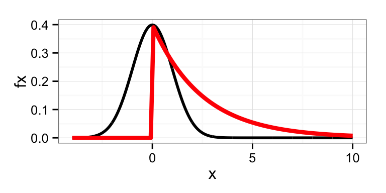

*Figure 1: A model graph of exponantial distribution overlayed on Normal distribution*

When measuring the amount of time waiting in queue, weather it is at Starbucks or local super market or waiting support call phone queue, exponential distribution is used to quantify the probability wait time. For example using (ED), you can say “there is 45% probability that the wait is less than 15 minutes”, or more than “ 30 minutes”, or between “10 and 20 minutes” for a given queue.

## Inferential Analysis Objectives:

The probability density function (pdf) for exponantial distribution is:

$f(x; \lambda ) = \begin{cases} \lambda e^{-\lambda x} & x\ge 0\\ 0 & x\le 0 \end{cases}$

The total area under the exponential distribution, like normal distribution, is equal to 1. And here is mathematical derivation:

$\int_{n=0}^{\infty} \lambda e^{-\lambda} = 1$

## Examine the Properties (Q 1 & 2):

The rate for this excersise is given $\lambda = 0.2$

The mean (expected value) of the exponentially distributed random variable X with rate parameter lambda is given by: $E[X] = 1 / \lambda - so we calculate the theoretical mean to be 1/0.2 = 5.$

The variability for is: $V[X] = 1/ \lambda ^2 - we calculate the theoretical variance 1/0.2 ^2 = 25$

There fore Standard Deviation is $SD[x] = \sqrt V[X] - we calculate the theoretical standard deviation \sqrt 25 = 5$

## Examine Eexponantial Distribution property for sampled & theoretical:

Here are the code chunks used to simulate exponantial distribution. The number of observation “n” is 40. The R function used to dervie the exponantial distribution is **“rexp”**. The code runs the “rexp”" function for 40 observation 1000 times.

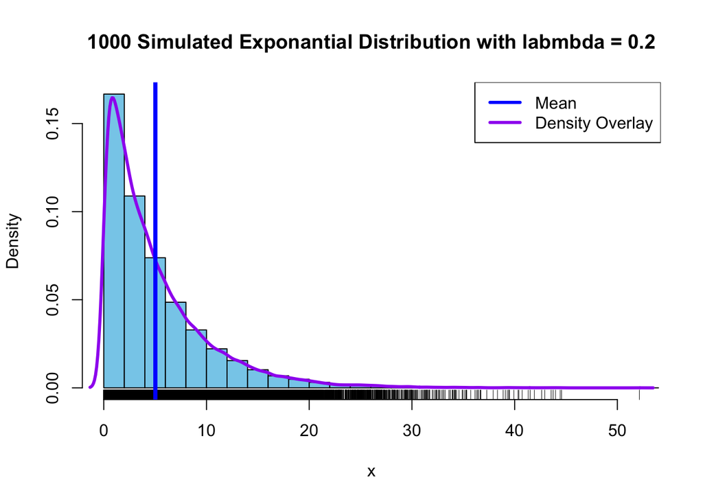

```r
x = NULL
#y = NULL
n <- 40 # number of observations
lambda <- .2 # rate \lambda

for (i in 1: 1000) x = c(x , rexp(n, lambda)) # 1000 simulation of ed

     hist(x,
     xlim = c(min(x), max(x)),
     #ylim = c(0, .6),
     breaks = 30,
     probability = T,
     col = "skyblue",
     main = "1000 Simulated Exponantial Distribution with labmbda = 0.2")

     lines(density(x), col='purple', lwd=3) #density map

rug(x)
abline(v = mean(x), col = "blue", lwd = 4)

legend(par('usr')[2], par('usr')[4], xjust=1,
       c('Mean', 'Density Overlay'),
       lwd=3,
       lty=1,
       col=c('blue', 'purple'))
```

*Figure 2: A1 000 Simulated Exponantial Distributions with lambda 0.2 with density overlay*

The Mean, variance and standard deviation for the exponantial distribution probablity are:

```r
mean(x)
```

```
## [1] 5.024136
```

```r
var(x)
```

```
## [1] 25.63484
```

```r
sd(x)
```

```
## [1] 5.063086
```

*Table 1: The theoretical and sample values for mean and variance*

| Properties | Sample | Theoretical |
| --- | --- | --- |
| mean | 5.0241363 | 5 |
| Variance | 25.6348412 | 25 |
| standard dev | 5.0630861 | 5 |

## Exponential Distribution to Central Limit Theorem inference (Q 3)

Here we run the average of the 40 observed exponantial distribution a 1,000 times, and generate a histogram. As we can see it resembles a resembles a normal distribution bell curv. Confirming the Central Limit Theory that the mean of a large sample distributions, regardless of the type of distribution, will approximately resemble a normal distribution.

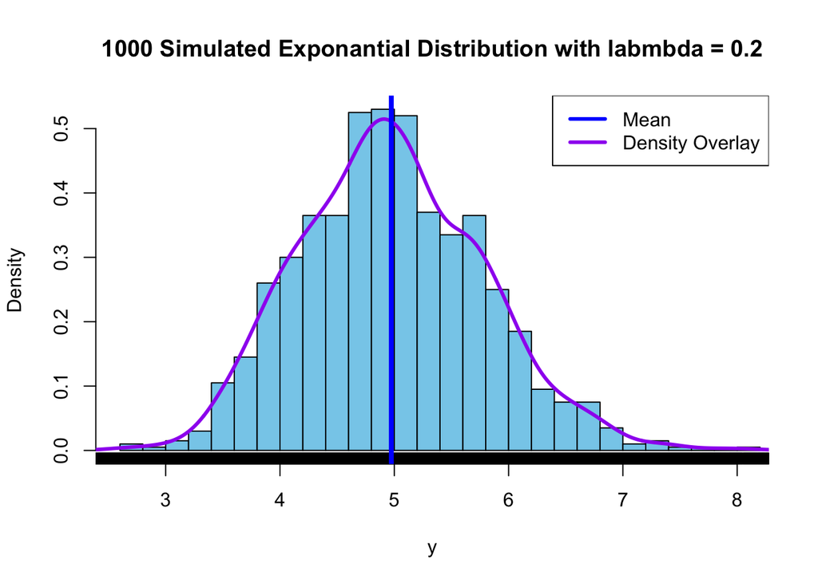

```r
y = NULL
#y = NULL
n <- 40 # number of observations
lambda <- .2 # rate \lambda

for (i in 1: 1000) y = c(y , mean(rexp(n, lambda))) # mean of 40 exp at a rate of .2

hist(y,
     xlim = c(min(y), max(y)),
     #ylim = c(0, .6),
     breaks = 30,
     probability = T,
     col = "skyblue",
     main = "1000 Simulated Exponantial Distribution with labmbda = 0.2")

    lines(density(y), col='purple', lwd=3) #density map
rug(x)
abline(v = mean(y), col = "blue", lwd = 4)

legend(par('usr')[2], par('usr')[4], xjust=1,
       c('Mean', 'Density Overlay'),
       lwd=3,
       lty=1,
       col=c('blue', 'purple'))
```

*Figure 3: A 1000 Simulated the averages of Exponantial Distributions with lambda 0.2 and density overlay*

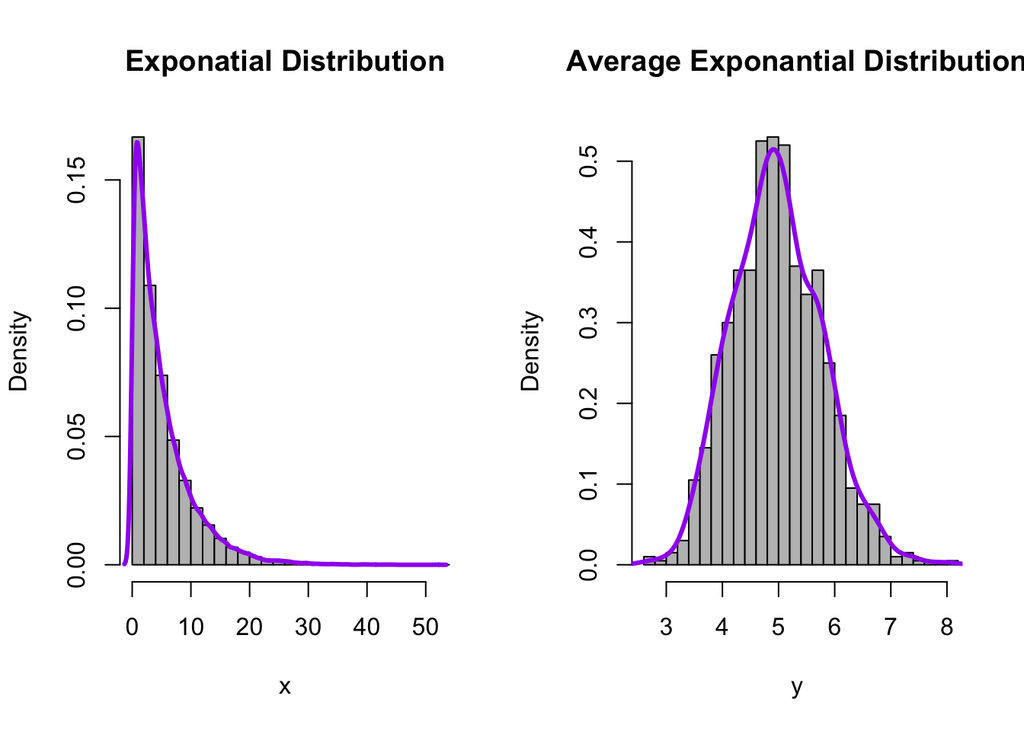

## Inferential observation:

The simulations and the analysis on this paper reveal that when sufficiently large, equally independent, sample random variables are fitted in an exponential distribution model, their properties, such as variability – mean – standard distribution, proves similar to the theoretical properties. And that, the arithmetic average of sufficiently large sampled exponential distribution show normal distribution tendency as postulated by the Central Limit Theorem.